# BIS180L Midterm 2023

**Spring, 2023**  
**Available May 05, 1:10 PM**  
**Due Thursday May 11, 1:10 PM**

**Student Name:** Ricardo Pineda

**Student ID:** 917486212

## Limitations

This exam is open book, open notes, open web **HOWEVER** You **CANNOT** discuss the questions with any person or entity.  
You **CANNOT** request help from any person, online forum, listserv, chatroom, or other entity, etc. You **MUST** Do your own work

You CAN ask John or Professor Maloof for clarification.

By typing my name below I affirm that I have read the above instructions and will follow them and the [UC Davis Academic Code](https://ossja.ucdavis.edu/code-academic-conduct).  
Name: Ricardo Pineda

## Instructions

1. Work by adding your answers to this .Rmd file
2. For all questions provide any code that you used to answer them formatted as a code block.
3. Include your code even if you can’t get it to work. You may get partial credit.
4. For R and relevant bash questions the code should run and embed the answers when you knit this file.
5. Save, commit, and push your .Rmd often. This gives you a backup of your work in case there are any computer crashes, etc.
6. When you are ready to turn in the exam, knit an html file add both the .Rmd an the .html file and push to your repository.

## Strategy

Everything here is based on something you have learned (although it may extend it). Your first resource should be the lab manuals, previous assignments, and your notes.

## Example 0

You should already be familiar with this, but if not: We can get Rmarkdown to run bash code when knitting, by replacing the “r” with “bash” inside the {}, as follows:

```bash
ls -lh #runs the bash ls command and displays output below
```

```
## total 1.2M
## -rw-rw-r-- 1 exouser exouser  14K May 11 10:34 Midterm_Template.Rmd
## -rw-rw-r-- 1 exouser exouser 1.2M May 11 10:34 Midterm_Template.html
```

Please use this for your bash answers below.

Remember that you can add eval=FALSE to keep the code chunk from running while knitting. You should do this for any code that should not run when knitting. (For example making a blast database that has already been made, or downloading a file that has already been downloaded).

```bash
ls -lh # won't run when knitted
```

One bummer is that tab-completion doesn’t work in Rstudio bash code chunks. If you are missing it you could type your commands into a bash terminal so that you can tab-complete, and the copy paste to here. If you do this, make sure that the working directory in your bash terminal is the same one as this script!!

## Question 1 (5 points)

Be sure that your knitted html is formatted well and that you use informative variable names in your code

## Question 2 (9 points)

**A:** *Use either bash or R to show the absolute path of the working directory*

```r
getwd()
```

```
## [1] "/home/exouser/Assignments/midterm-rhpineda/scripts"
```

OR

```bash
pwd
```

```
## /home/exouser/Assignments/midterm-rhpineda/scripts
```

**B:** _What is the absolute path to the file `where_am_I.txt`, located in the `input` directory of the repository? (no code needed)

- /home/exouser/Assignments/midterm-rhpineda/input/where_am_I.txt

**C:** *What is the relative path from the directory shown in your answer **A:** above to the `where_am_I.txt` file? (no code needed)*

- ../input/where_am_I.txt

## Question 3 (27 points)

**A: (4 pts)** *You have cloned a gene of interest from the Eastern Monarch Butterfly population and you want to find its ortholog in Western Butterfly via a nucleotide BLAST search. You expect the sequences to be very similar. Considering the word sizes we looked at in the BLAST lab, what word size you use? Why? (Conceptual question, no code needed)*

- I would use a word size of 13. In the lab it was discussed that dc-megablast and blastn are both used to find similarities between interspecial sequences. I assume the default of 11 but a bit longer is a good balance between being sensitive enough to capture the ortholog I’m looking for, but specific enough to exclude a lot of suboptimal hits.

**B: (4 pts)** *Will your choice in part **A** cause an increased or decreased sensitivity (ability to detect distant homologs)? Why? (Conceptual question, no code needed)*

- This will cause a decrease in sensitivity compared to the default or any other smaller word size. This is because fewer seeds will be found with a longer word size and fewer seeds lead to fewer hits to possible orthologs.

**C: (4pts)** *If you wanted to blast all of the genes in the Eastern Monarch Butterfly genome against those in the Western Monarch Butterfly genome to find orthologs (with highly similar sequence) would that change your word size choice?*

- I might want to increase the word size if the compute time for the single gene of interest blast took too long. I would want to increase the word size because it further decreases sensitivity so that means that the algorithm will look through fewer seeds so less compute time will be required.

**D: (11 pts)** *You have cloned a Monarch gene that you think may be involved in their migration. The PROTEIN sequence (MysteryProtein.fa) is in your `input` directory. You want to blast it against the *Bombyx mori* (silkworm) PROTEOME to determine its likely identity. A file with *Bombyx mori* PROTEINS (`Bombyx_mori.Bmori_2016v1.0.pep.all.fa.gz`) is in your `input` directory. Using the appropriate BLAST program, find the most plausible identity and description of the mystery protein. Include all code used to answer this question.*

*HINT1: The correct BLAST program might be one you haven’t used yet, but it is discussed in the lecture*

*HINT2: If BLAST just returns a protein ID but no description, you can find the decsiption by looking at the full FASTA header for that protein*

```bash
gunzip ../input/Bombyx_mori.Bmori_2016v1.0.pep.all.fa.gz
makeblastdb -in ../input/Bombyx_mori.Bmori_2016v1.0.pep.all.fa -dbtype prot

#leaving out the -eval parameter gives hits with really big evaules like 3
#I could've also done -max_target_seqs
blastp -db ../input/Bombyx_mori.Bmori_2016v1.0.pep.all.fa -query ../input/MysteryProtein.fa  -evalue 1e-3 > ../output/blastout.default
#best hit and hit info
head -42 blastout.default  | tail -15
```

[output not shown]

```
## gzip: ../input/Bombyx_mori.Bmori_2016v1.0.pep.all.fa.gz: No such file or directory
##
##
## Building a new DB, current time: 05/11/2023 10:42:02
## New DB name:   /home/exouser/Assignments/midterm-rhpineda/input/Bombyx_mori.Bmori_2016v1.0.pep.all.fa
## New DB title:  ../input/Bombyx_mori.Bmori_2016v1.0.pep.all.fa
## Sequence type: Protein
## Deleted existing Protein BLAST database named /home/exouser/Assignments/midterm-rhpineda/input/Bombyx_mori.Bmori_2016v1.0.pep.all.fa
## Keep MBits: T
## Maximum file size: 3000000000B
## Adding sequences from FASTA; added 27303 sequences in 0.666546 seconds.
##
##
## head: cannot open 'blastout.default' for reading: No such file or directory
```

## Question 4 (10 points)

*The directory on your JetStream instance `/home/exouser/data/A.thaliana` contains eight gzipped files. Write a for loop that for each file prints the name of the file and the number of lines in the unzipped file. For example, if there was a file `Chr6.fa.gz`, your code would produce the output “Chr6.fa.gz contains 473 lines”. Do this without saving unzipped files to disk.*

```bash
arabidopsis=$(ls ~/data/A.thaliana/)
for file in $arabidopsis
  do
    echo ${file} contains $(zless ~/data/A.thaliana/${file} | wc -l) lines
  done
```

```
## Araport11_genes.201606.pep.fasta.gz contains 55310 lines
## Chr1.fa.gz contains 434683 lines
## Chr2.fa.gz contains 281406 lines
## Chr3.fa.gz contains 335142 lines
## Chr4.fa.gz contains 265502 lines
## Chr5.fa.gz contains 385366 lines
## chloroplast.fa.gz contains 2208 lines
## mitochondria.fa.gz contains 5243 lines
```

## Question 5 (28 points)

*This question is about the relationship between animal body weight and lifespan. In the input folder the file `animal_data.csv` contains a variety of measurements on animals including body weight and longevity. The file `animal_taxa.csv` gives taxonomic data for animals (e.g. order, family, genus, species).*

**A:** *Import the two files. Check the import using appropriate functions; any issues?*

- Initially there was an error with function not being found, have to load in the tidyverse library.

```r
library(tidyverse)
animal_data <- read_csv("../input/animal_data.csv")
animal_taxa <- read.csv("../input/animal_taxa.csv")
```

**B:** *Combine the two dataframes from **A** into a single data frame. The column `HAGRID` is an ID column common to both data sheets. Note that the `taxa` data has more rows than the `data` file. We only want to retain rows where there is an entry in both files. Explain your choice of function.*

- Look data to know what to join with what
  - Want to create a data frame that’s shared b/w the two
  - Only want observations where there is HARGRID in both dataframes
- I initially used both `inner_join` and `left_join` with `animal_data` as the one on the left since I thought they did the same thing and it turns out they did do the same thing. I thought they would do the same thing because using `inner_join` should keep only the observations while `left_join` merges the right dataframe into the left one if there’s a match.

```r
#head(animal_data)
#head(animal_taxa)
#names(animal_data)
#print("--------------")
#names(animal_taxa)

animal_data_taxa_inner <- inner_join(animal_data,animal_taxa, by = "HAGRID")
animal_data_taxa_inner
```

| HAGRID | Female.maturity..days | Male.maturity..days | Gestation.Incubation..days | Birth.weight..g | Maximum.longevity..yrs | Metabolic.rate..W | Body.mass..g | Temperature..K | Log10.Body.mass..g | Kingdom | Phylum | Class | Order | Family | Genus | Species | Common.name |
| --- | --- | --- | --- | --- | --- | --- | --- | --- | --- | --- | --- | --- | --- | --- | --- | --- | --- |
| 18 | 910 | 910 | 8 | NA | 36.0 | 0.008290 | 21.60 | 288.00 | 1.3344538 | Animalia | Chordata | Amphibia | Anura | Bufonidae | Anaxyrus | americanus | American toad |
| 26 | NA | NA | 3 | NA | 10.0 | 0.006980 | 19.20 | 288.00 | 1.2833012 | Animalia | Chordata | Amphibia | Anura | Bufonidae | Anaxyrus | terrestris | Southern toad |
| 36 | 365 | 365 | 2 | NA | 24.8 | 0.030300 | 105.00 | 293.00 | 2.0211893 | Animalia | Chordata | Amphibia | Anura | Bufonidae | Rhinella | marina | Cane toad |
| 60 | 730 | 730 | 4 | NA | 7.8 | 0.004330 | 6.97 | 290.50 | 0.8432328 | Animalia | Chordata | Amphibia | Anura | Hylidae | Hyla | versicolor | Gray treefrog |
| 85 | 183 | NA | 2 | NA | 30.3 | 0.012000 | 63.60 | 288.00 | 1.8034571 | Animalia | Chordata | Amphibia | Anura | Pipidae | Xenopus | laevis | African clawed frog |
| 88 | 1277 | 730 | 4 | NA | 16.0 | 0.013400 | 51.20 | 288.00 | 1.7092700 | Animalia | Chordata | Amphibia | Anura | Ranidae | Lithobates | catesbeianus | American bullfrog |
| 90 | 730 | 365 | NA | NA | 9.0 | 0.005760 | 21.60 | 289.78 | 1.3344538 | Animalia | Chordata | Amphibia | Anura | Ranidae | Lithobates | pipiens | Northern leopard frog |
| 111 | 1095 | 730 | NA | NA | 32.0 | 0.005000 | 12.80 | 290.00 | 1.1072100 | Animalia | Chordata | Amphibia | Caudata | Ambystomatidae | Ambystoma | maculatum | Spotted salamander |
| 117 | 1460 | 1460 | 28 | NA | 25.0 | 0.001960 | 3.21 | 291.00 | 0.5065050 | Animalia | Chordata | Amphibia | Caudata | Ambystomatidae | Ambystoma | tigrinum | Tiger salamander |
| 119 | 1460 | 1095 | 150 | NA | 27.0 | 0.009040 | 199.00 | 288.00 | 2.2988531 | Animalia | Chordata | Amphibia | Caudata | Amphiumidae | Amphiuma | means | Two-toed amphiuma |

[output cut: 526 more lines]

```r
#str(animal_data_taxa_inner)

#innerjoin gives an identical dataframe as using left join with the left being the smaller dataframe in this case.
#animal_data_taxa_left <- left_join(animal_data,animal_taxa, by = "HAGRID")
#animal_data_taxa_left
#identical(animal_data_taxa_inner, animal_data_taxa_left) #Ended up returning TRUE
```

**C:** *We will focus on mammals. Filter the dataframe from **B** to keep only mammals*

```r
mammal_data <- filter(animal_data_taxa_inner, Class == "Mammalia")
mammal_data
```

| HAGRID | Female.maturity..days | Male.maturity..days | Gestation.Incubation..days | Birth.weight..g | Maximum.longevity..yrs | Metabolic.rate..W | Body.mass..g | Temperature..K | Log10.Body.mass..g | Kingdom | Phylum | Class | Order | Family | Genus | Species | Common.name |
| --- | --- | --- | --- | --- | --- | --- | --- | --- | --- | --- | --- | --- | --- | --- | --- | --- | --- |
| 1542 | 365 | 365 | 55 | 7.6700e+00 | 19.0 | 0.75000 | 116.4 | 307.85 | 2.0659530 | Animalia | Chordata | Mammalia | Afrosoricida | Tenrecidae | Echinops | telfairi | Lesser hedgehog tenrec |
| 1545 | 669 | 669 | 61 | 3.9500e+00 | 5.6 | 0.31500 | 44.6 | 304.05 | 1.6493349 | Animalia | Chordata | Mammalia | Afrosoricida | Tenrecidae | Microgale | dobsoni | Dobson's shrew tenrec |
| 1546 | 639 | 639 | 61 | 3.6000e+00 | 5.8 | 0.24300 | 44.0 | 303.95 | 1.6434527 | Animalia | Chordata | Mammalia | Afrosoricida | Tenrecidae | Microgale | talazaci | Talazac's shrew tenrec |
| 1547 | 198 | 258 | 54 | 2.4700e+01 | 14.1 | 0.57300 | 427.6 | 305.35 | 2.6310377 | Animalia | Chordata | Mammalia | Afrosoricida | Tenrecidae | Setifer | setosus | Greater hedgehog tenrec |
| 1548 | 182 | NA | 58 | 2.1000e+01 | 8.7 | 0.72900 | 650.0 | 306.15 | 2.8129134 | Animalia | Chordata | Mammalia | Afrosoricida | Tenrecidae | Tenrec | ecaudatus | Tenrec |
| 1549 | 547 | 547 | 235 | 3.0000e+03 | 15.5 | 50.97300 | 34779.3 | 311.15 | 4.5413208 | Animalia | Chordata | Mammalia | Artiodactyla | Antilocapridae | Antilocapra | americana | Pronghorn |
| 1591 | 411 | 912 | 253 | 1.8125e+04 | 24.3 | 230.07300 | 196500.0 | 311.15 | 5.2933626 | Animalia | Chordata | Mammalia | Artiodactyla | Bovidae | Connochaetes | taurinus | Blue wildebeest |
| 1608 | 771 | NA | 264 | 9.0000e+03 | 30.0 | 148.94900 | 100000.0 | 311.85 | 5.0000000 | Animalia | Chordata | Mammalia | Artiodactyla | Bovidae | Kobus | ellipsiprymnus | Waterbuck |
| 1614 | 213 | 304 | 172 | 6.0000e+02 | 17.3 | 11.96600 | 4290.0 | 312.15 | 3.6324573 | Animalia | Chordata | Mammalia | Artiodactyla | Bovidae | Madoqua | kirkii | Kirk's dik-dik |
| 1623 | 912 | 912 | 184 | 3.2000e+03 | 20.8 | 46.41400 | 32000.0 | NA | 4.5051500 | Animalia | Chordata | Mammalia | Artiodactyla | Bovidae | Oreamnos | americanus | Mountain goat |

[output cut: 332 more lines]

**D:** *For this question we will look at variation in longevity only in Primates. Filter the dataframe from **C** to retain only Primates and then make a boxplot that displays `Maximum.longevity..yrs` for each Family. To get the Family names to display nicely add this to your ggplot code: `theme(axis.text.x=element_text(angle=90, hjust=1, vjust=0.5))`. You will need a `+` on the line before that code.*

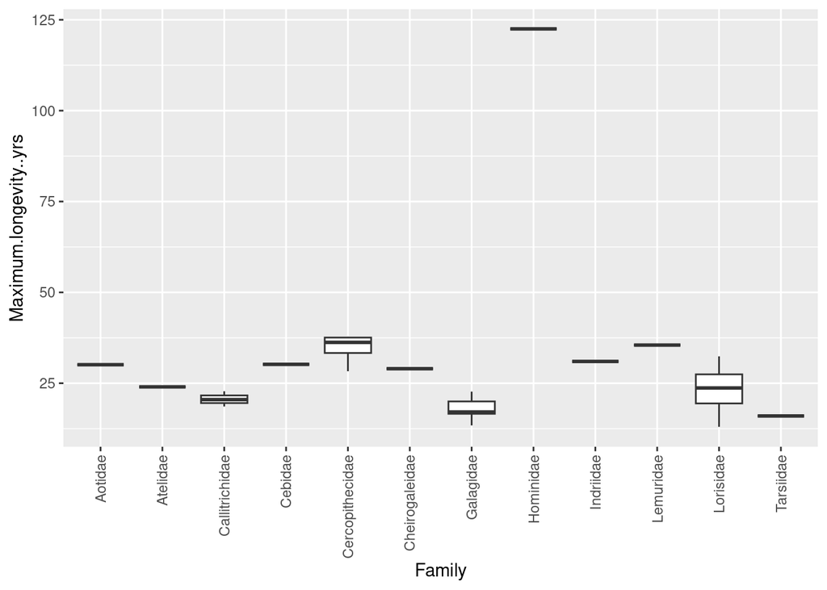

```r
#x <- filter(data, column == "what you want")
primate_data <- filter(mammal_data, Order == "Primates")

ggplot(data = primate_data, aes(x =Family, y = Maximum.longevity..yrs)) +
  geom_boxplot() +
  theme(axis.text.x=element_text(angle=90, hjust=1, vjust=0.5))
```

**E:** *Is there an outlier in the plot from **D**? If so, what is it?*

- Yes, Hominidae.

**F:** *Let’s go back to looking at all mammals; for this question start from the data frame from **C**. If you identified an outlier in **D/E**, remove it, then use a scatter plot to examine the relationship between `Maximum.longevity..yrs` and `Log10.Body.mass..g`*

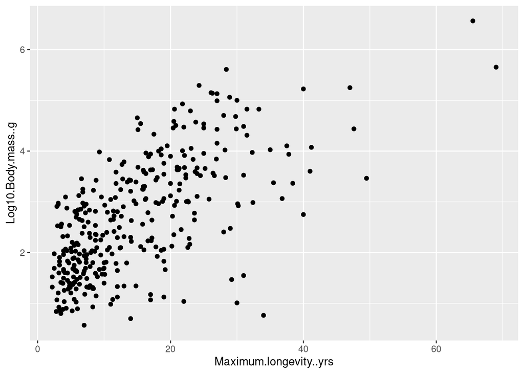

```r
mammal_data_nohomonids <- mammal_data[mammal_data$Family != "Hominidae",]
ggplot(data = mammal_data_nohomonids, aes(x = Maximum.longevity..yrs, y = Log10.Body.mass..g)) +
  geom_point()
```

```r
# plot still with Hominidae
#ggplot(data = mammal_data, aes(x = Maximum.longevity..yrs, y = Log10.Body.mass..g)) +
#  geom_point()
```

**G:** *What does **F** tell you about the relationship between longevity and body mass?*

- Generally as the mass of an organism increases, so does its longevity.

## Question 6 (16 points)

*Answer the questions IN YOUR OWN WORDS. Although it is OK to research on the web, DO NOT COPY YOUR DESCRIPTONS FROM THE WEB, WE WILL BE CHECKING.*

**No code needed for these questions**

**A** *When do you use `git add` and when do you use `git commit`? How are these related and what makes them different?*

- I would use `git add` to add some file to be tracked by git and I would use `git commit` when I want some file that’s tracked and changed to be ready to be pushed to git to be saved there. These are related because they are both relate adding files to be ready to saved onto git. They differ in function with how often you have to do it for each file. You usually only have to `git add` a file once while you have to `git commit` before pushing it to git to be saved.

**B** *What is the difference between `git commit` and `git push`? How are these related and what makes them different?*

- Git commit is like saying you are ready to save changes to a tracked file and git push is actually saving changes to a file to git. They are related to saving files on git. They are different as commiting changes doesn’t lock you in to those changes and you can easily undo those changes. Pushing really saves changes onto git but it’s also hard enough that we had a lab on how to undo bad pushes.

**C** *Compare and contrast `git pull` and `git clone`: how are these related and what makes them different?*

- `Git pull` checks git and adds the changes from git that are not saved onto your local repo. `git clone` copies the entirety of a git repo locally. They are related as both commands checks git and brings files onto your system. They differ as git pull is used to update the local repo to what it’s like on git while git clone makes a whole copy.

**D** *Compare and contrast `git clone` and `git fork`: how are these related and what makes them different?*

- `git clone` copies the entirety of a git repo locally. `git fork` is used to make a new copy of an original repo on github that is now separate from the original one. They are related both make copies of a repo. They are different because cloning will still lead to pushing to the original repo without doing some other stuff with git, while forking leads to a new copy of a repo on git that you own but not necessarily on your machine unless you also clone it.

## Question 7 (5 points)

*This has been a super year for wildflowers.*

**A** *Using markdown notation, provide us with a link to a website of a wildflower that you like. (We do not want to see any URLs in the knitted html)*

- [Here’s the link!](https://www.inaturalist.org/guide_taxa/530638)

*(If you don’t know where to start, you can just link to the wikipedia page for California Poppy)*

**B** *Now that we have a link to a website, using markdown notation, attach an image of the wildflower*

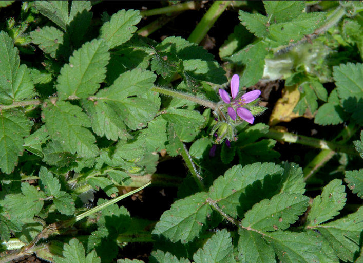